# Lab 4

Ann Gould and Henry Underhill

# Libraries

```r
library(readxl)
library(tidyverse)
library(dplyr)
```

# Loading Data

```r
defense <- read_excel('cyclonesFootball2019.xlsx', sheet='Defensive')
biography <- read_excel('cyclonesFootball2019.xlsx', sheet='Biography')
offensive <- read_excel('cyclonesFootball2019.xlsx', sheet='Offensive')
str(defense)
```

```
## Classes 'tbl_df', 'tbl' and 'data.frame':    502 obs. of  11 variables:
##  $ Name             : chr  "White, Lawrence" "White, Lawrence" "White, Lawrence" "White, Lawrence" ...
##  $ Opponent_Opponent: chr  "UNI" "Iowa" "ULM" "Baylor" ...
##  $ Tackles_Solo     : chr  "4" "4" "3" "4" ...
##  $ Tackles_ASST     : chr  "4" "7" "5" "2" ...
##  $ Tackles_TFL      : chr  "0" "0" "0" "0" ...
##  $ Tackles_Sack     : chr  "0" "0" "0" "0" ...
##  $ Turnover_FF      : chr  "0" "0" "0" "0" ...
##  $ Turnover_FR      : chr  "0" "0" "0" "0" ...
##  $ Turnover_INT     : chr  "0" "0" "1" "0" ...
##  $ Pass_QBH         : chr  "1" "0" "0" "0" ...
##  $ Pass_PB          : chr  "1" "2" "0" "0" ...
```

# Cleaning Data

```r
defense$Name <- as.factor(defense$Name) # 1
defClean <- defense
biography$Name <- as.factor(biography$Name) # 1

biography$Weight <- as.numeric(biography$Weight) # 2
bioClean = biography %>% separate(Height, c("Ft", "In"))


offensive$Name <- as.factor(offensive$Name)
offClean <- offensive




# defense
biography
```

| Name | Position | Height | Weight | Class | Hometown | Highschool |
| --- | --- | --- | --- | --- | --- | --- |
| Akers, Landen | Wide Receiver | 6-0 | 188 | Redshirt Senior | Cedar Rapids, Iowa | Washington |
| Allen, Chase | Tight End | 6-7 | 245 | Redshirt Senior | Nixa, Mo. | Nixa |
| Anderson, Ezeriah | Wide Receiver | 6-5 | 204 | Redshirt Freshman | Seffner, Fla. | Armwood |
| Assalley, Connor | Placekicker | 6-0 | 195 | Redshirt Senior | Naperville, Ill. | Central |
| Azunna, Arnold | Defensive Back | 6-0 | 190 | Redshirt Senior | Grand Prairie, Texas | Lake Ridge |
| Bailey, Cordarrius | Defensive End | 6-3 | 235 | Redshirt Junior | Clarksdale, Miss. | Clarksdale |
| Bailey, JaQuan | Defensive End | 6-2 | 255 | Redshirt Senior | Jacksonville, Fla. | Raines |
| Bailey, Joshua | Defensive Line | 6-2 | 285 | Redshirt Senior | Jacksonville, Fla. | Raines |
| Bankston, Latrell | Defensive Line | 6-0 | 300 | Junior | Woodstock, Ga. | Woodstock |
| Bouman, Aidan | Quarterback | 6-6 | 215 | Freshman | Buffalo, Minn. | Buffalo |

[output cut: 95 more lines]

```r
print(defense)
```

```
## # A tibble: 502 x 11
##    Name  Opponent_Oppone~ Tackles_Solo Tackles_ASST Tackles_TFL Tackles_Sack
##    <fct> <chr>            <chr>        <chr>        <chr>       <chr>
##  1 Whit~ UNI              4            4            0           0
##  2 Whit~ Iowa             4            7            0           0
##  3 Whit~ ULM              3            5            0           0
##  4 Whit~ Baylor           4            2            0           0
##  5 Whit~ TCU              3            2            1.0         0
##  6 Whit~ West Virginia    1            1            0           0
##  7 Whit~ Texas Tech       7            1            0           0
##  8 Whit~ Oklahoma State   3            2            0           0
##  9 Whit~ Oklahoma         6            1            1.0         0
## 10 Whit~ Texas            5            5            1.0         1.0
## # ... with 492 more rows, and 5 more variables: Turnover_FF <chr>,
## #   Turnover_FR <chr>, Turnover_INT <chr>, Pass_QBH <chr>, Pass_PB <chr>
```

```r
print(offensive)
```

```
## # A tibble: 195 x 12
##    Name  Opponent_Oppone~ Rushing_ATT Rushing_YDS Rushing_TD Receiving_REC
##    <fct> <chr>            <chr>       <chr>       <chr>      <chr>
##  1 Aker~ UNI              0           0           0          1
##  2 Aker~ Iowa             0           0           0          0
##  3 Aker~ ULM              1           8           0          0
##  4 Aker~ Baylor           0           0           0          0
##  5 Aker~ TCU              0           0           0          1
##  6 Aker~ West Virginia    0           0           0          0
##  7 Aker~ Texas Tech       0           0           0          0
##  8 Aker~ Oklahoma State   0           0           0          4
##  9 Aker~ Oklahoma         0           0           0          0
## 10 Aker~ Texas            0           0           0          1
## # ... with 185 more rows, and 6 more variables: Receiving_YDS <chr>,
## #   Receiving_TD <chr>, `Passing_CMP-ATT` <chr>, Passing_YDS <chr>,
## #   Passing_TD <chr>, Passing_INT <chr>
```

# Question 1

```r
defClean <- defense %>%
  pivot_longer(Tackles_Solo:Pass_PB, names_to = 'Statistic', values_to='Value')
head(defClean)
```

| Name | Opponent_Opponent | Statistic | Value |
| --- | --- | --- | --- |
| White, Lawrence | UNI | Tackles_Solo | 4 |
| White, Lawrence | UNI | Tackles_ASST | 4 |
| White, Lawrence | UNI | Tackles_TFL | 0 |
| White, Lawrence | UNI | Tackles_Sack | 0 |
| White, Lawrence | UNI | Turnover_FF | 0 |
| White, Lawrence | UNI | Turnover_FR | 0 |

# Question 2

The three rarest defensive statistics are Turnover_FF, TUrnover_FR, Turnover_INT. Turnovers are the rarest defensive plays seen in a football game.

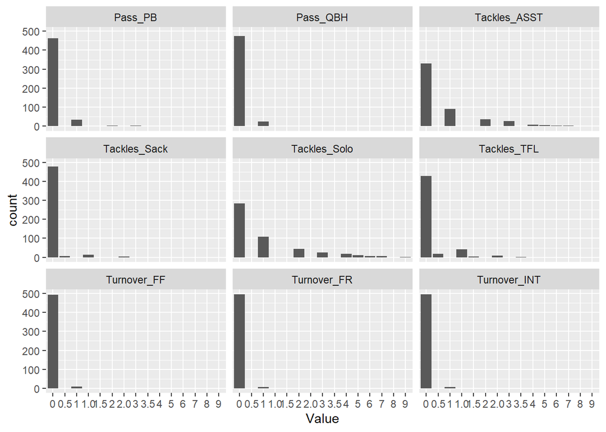

```r
ggplot(defClean, aes(x=Value)) +
    geom_histogram(stat="count") +
    facet_wrap(. ~ Statistic)
```

# Question 3

There are plenty of points towards zero, which leads the data to be difficult to interpret. There are a few far points that suggest the Iowa State defense is better against West Viriginia.

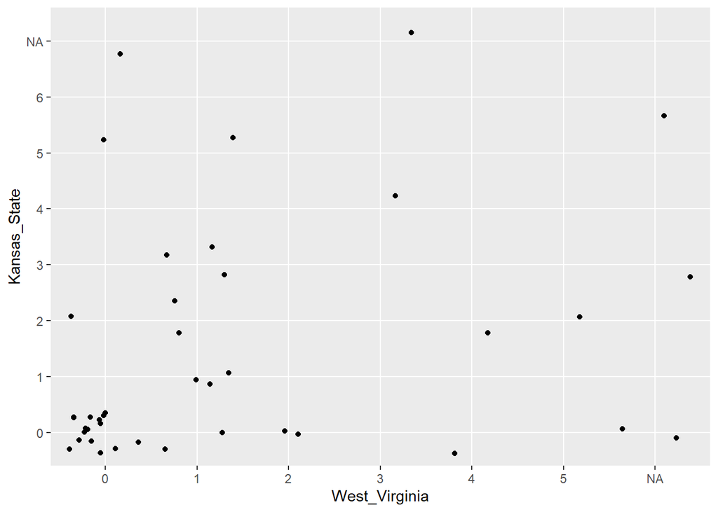

```r
def_Tackles_Solo = defClean %>%
  filter(Statistic == 'Tackles_Solo') %>%
  filter(Opponent_Opponent %in% c('West Virginia', 'Kansas State')) %>%
  pivot_wider(names_from=Opponent_Opponent, values_from=Value)

colnames(def_Tackles_Solo) = c('Name', 'Statistic', 'West_Virginia', 'Kansas_State')
ggplot(def_Tackles_Solo, aes(x=West_Virginia, y=Kansas_State)) + geom_smooth(method='lm') + geom_point(position='jitter')
```

# Tidying Part 2

# Question 1

```r
bioClean = bioClean %>% separate(Hometown, c('City', 'State'), sep=',', remove=FALSE)

head(bioClean['City'])
```

| City |
| --- |
| Cedar Rapids |
| Nixa |
| Seffner |
| Naperville |
| Grand Prairie |
| Clarksdale |

```r
head(bioClean['State'])
```

| State |
| --- |
| Iowa |
| Mo. |
| Fla. |
| Ill. |
| Texas |
| Miss. |

#Question 2

```r
eachState = bioClean %>% group_by(State) %>% tally()

print(eachState)
```

```
## # A tibble: 19 x 2
##    State            n
##    <chr>        <int>
##  1 " Ariz."         4
##  2 " Ark."          1
##  3 " Australia"     1
##  4 " Calif."        3
##  5 " Fla."         10
##  6 " Ga."           4
##  7 " Ill."          5
##  8 " Iowa"         35
##  9 " Kan."          3
## 10 " Mich."         4
## 11 " Minn."         4
## 12 " Miss."         1
## 13 " Mo."           6
## 14 " Ohio"          7
## 15 " Okla."         2
## 16 " Pa."           1
## 17 " S.D."          2
## 18 " Texas"         6
## 19 " Wis."          6
```

# Joining

#Question 1

```r
offComeFrom = full_join(offClean, bioClean, by="Name") %>% select(Name, Hometown) %>% distinct()
head(offComeFrom)
```

| Name | Hometown |
| --- | --- |
| Akers, Landen | Cedar Rapids, Iowa |
| Soehner, Dylan | Prairie Grove, Ark. |
| Allen, Chase | Nixa, Mo. |
| Wilson, Darren | Alpharetta, Ga. |
| Kolar, Charlie | Norman, Okla. |
| Pettway, La'Michael | NA |

# Question 2

The relationship is skewed towards lower weight values, with most players being below 215 pounds. There is a slight linear relationship, but only slightly to suggest that players of lower weight average slightly higher receiving.

```r
weightAndReceiving = inner_join(bioClean, offClean, by="Name") %>%
           select(Name, Weight, Receiving_YDS) %>%
           group_by(Name) %>%
           mutate(avgReceiving = mean(Receiving_YDS))
```

[output not shown]

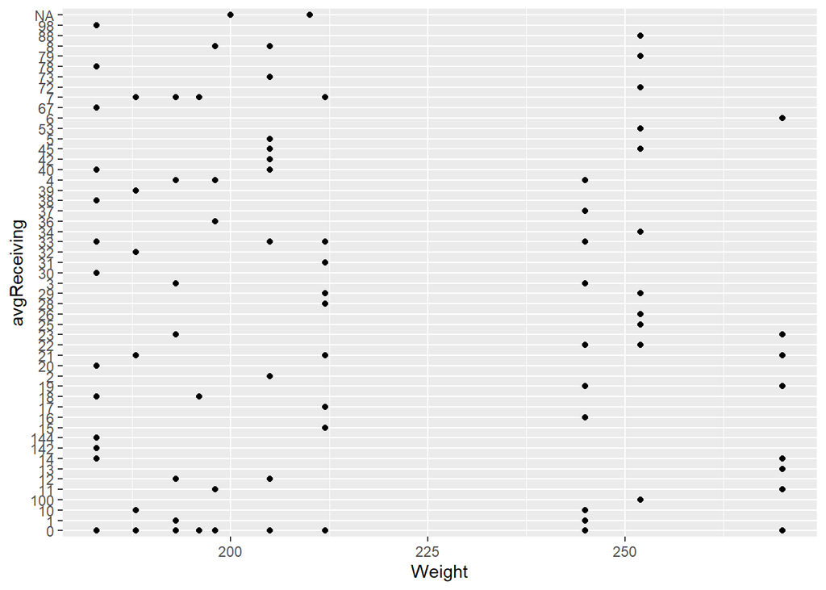

```r
ggplot(distinct(weightAndReceiving, Name), aes(x=Weight, y=avgReceiving)) +
    geom_point(data=weightAndReceiving, aes(x=Weight, y=Receiving_YDS))
```

# Question 3

Brock Purdy is far and away the best passer on the team. The other players with non-zero passing yards never top 100 yards, while Brock tops 100 for every game.

```r
offPassing = full_join(bioClean, offClean, by='Name') %>% group_by(Name) %>% select(Name, Passing_YDS)
```

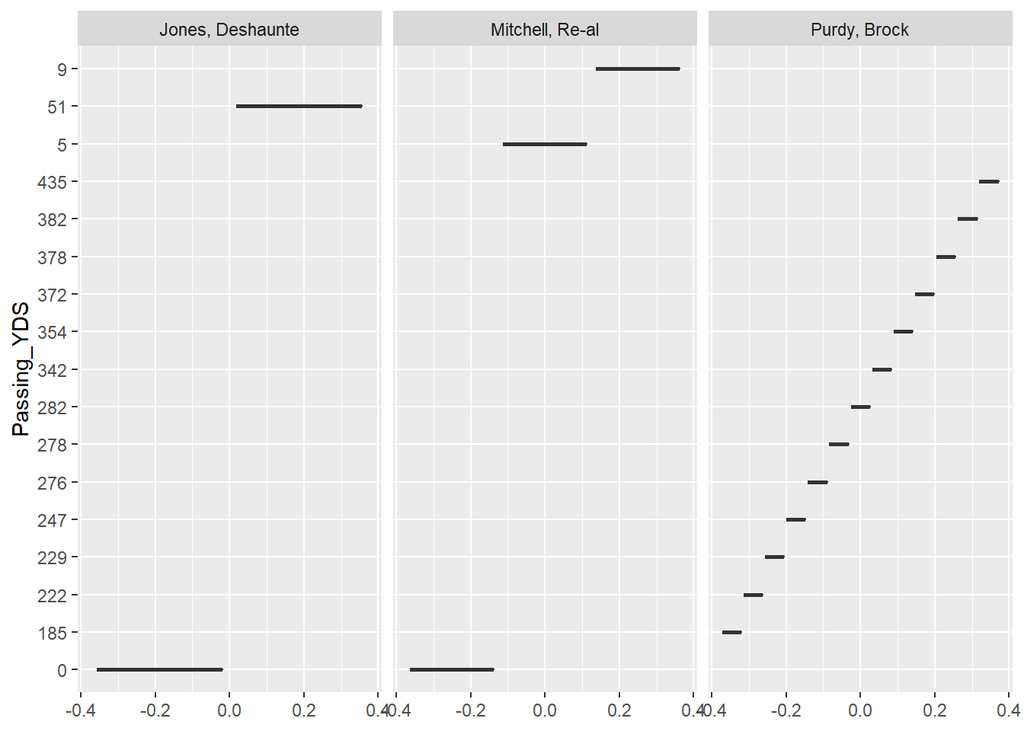

```r
#remove those with no passing yds
offPassing = na.omit(offPassing)


ggplot(offPassing, aes(y=Passing_YDS)) + geom_boxplot() + facet_wrap(~Name)
```

# Question 4

# Which player averaged the most rushing yards per game? Which player scored the most rushing touchdowns?

Brock Purdy and Breece Hall average consistent games with rushing attempts, along with consistent values with higher rushing yards. Brock Purdy and Breece Hall are also the only players to score 3 touchdowns in a game. Hall and Purdy had nearly identical frequency in their touchdown rates.

```r
offRushing = full_join(bioClean, offClean, by='Name') %>% group_by(Name) %>% select(Name, Rushing_YDS, Rushing_TD, Rushing_ATT)
```

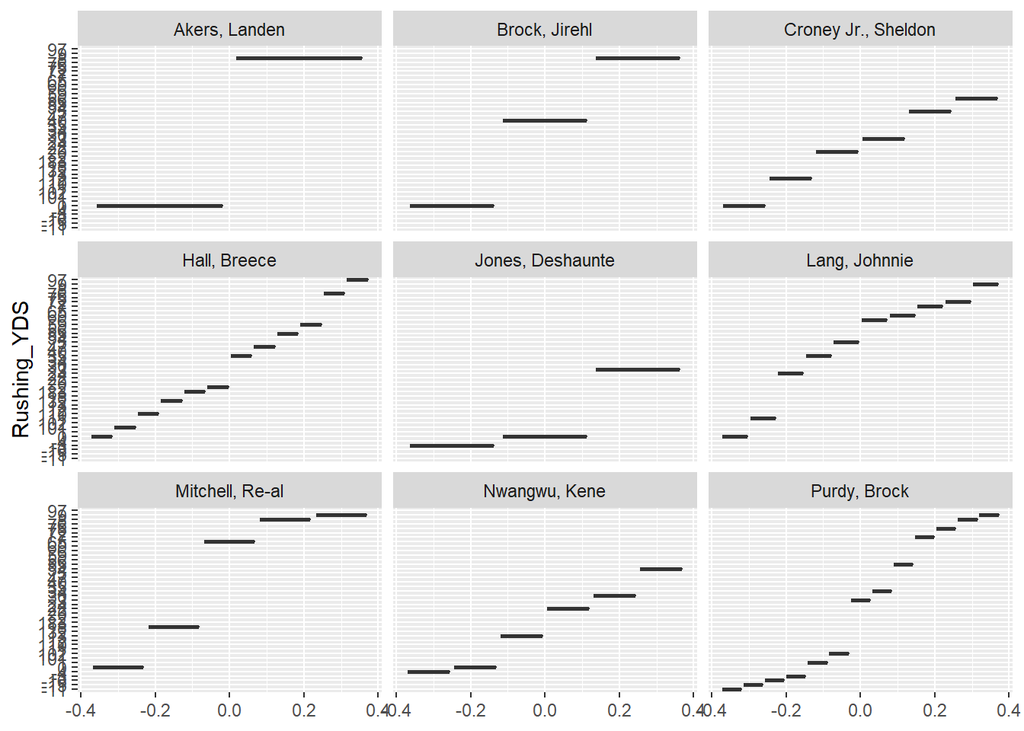

```r
#remove those with no rushing
offRushing = na.omit(offRushing)

ggplot(offRushing, aes(y=Rushing_YDS)) + geom_boxplot() + facet_wrap(~Name)
```

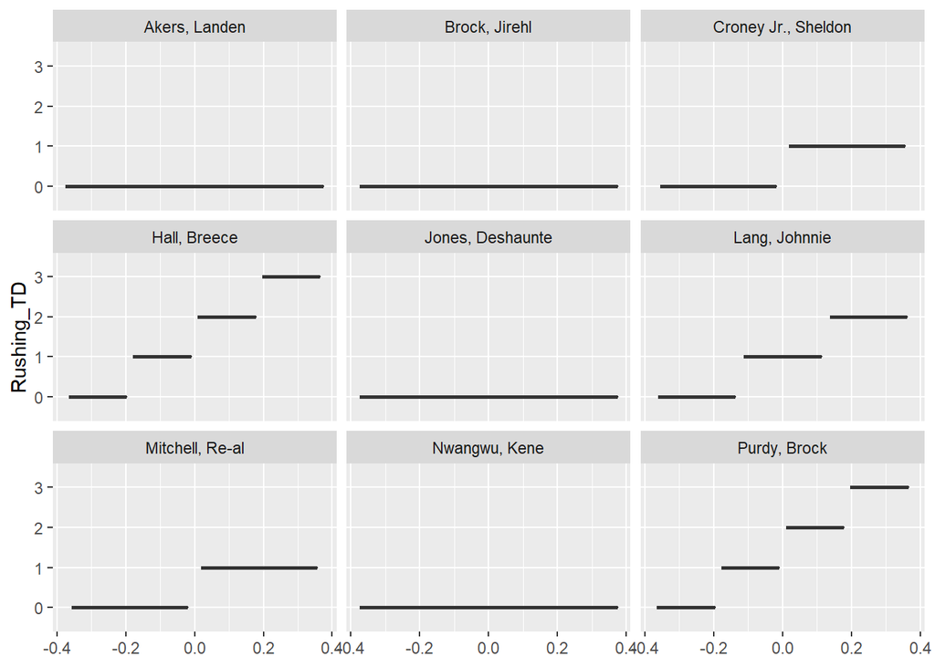

```r
ggplot(offRushing, aes(y=Rushing_TD)) + geom_boxplot() + facet_wrap(~Name)
```